# Coding test results

### Question 1 :

If we list all the natural numbers below 10 that are multiples of 3 or 5, we get 3, 5, 6 and 9. The sum of these multiples is 23. Find the sum of all the multiples of 3 or 5 below 1000.

R was used to answer this question.

**The result provided by the candidate reads:**

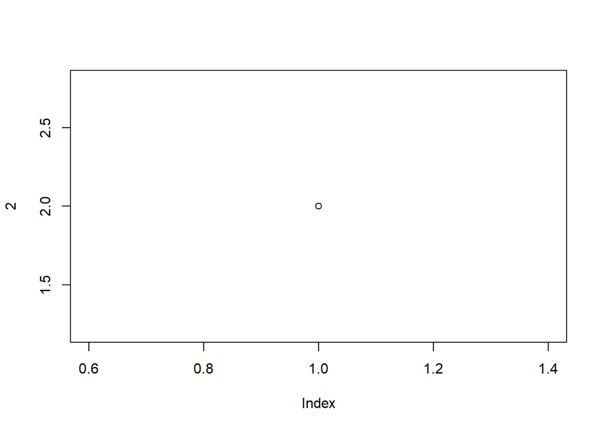

**The code provided by the candidate reads:**

```r
plot(2)
```

The candidate used 2 hints.

### Question 2 :

Make a query to get the average temperature in May (Month 5).

SQL was used to answer this question.

**The result provided by the candidate reads:**

| Ozone | Solar.R | Wind | Temp | Month | Day |
| --- | --- | --- | --- | --- | --- |
| 41 | 190 | 7.4 | 67 | 5 | 1 |
| 36 | 118 | 8.0 | 72 | 5 | 2 |
| 12 | 149 | 12.6 | 74 | 5 | 3 |
| 18 | 313 | 11.5 | 62 | 5 | 4 |
| NA | NA | 14.3 | 56 | 5 | 5 |

**The code provided by the candidate reads:**

```r
SELECT * FROM airquality LIMIT 5
```

The candidate used 0 hints.

### Question 3 :

Classical FizzBuzz: Print every number between 1 and 100, However for numbers that are multiples of 3 print “Fizz” and for numbers that are multiples of five print “Buzz.” For numbers that are multiples of both 3 and 5 print “FizzBuzz”.

**The applicant did not provide code.**

### Question 4 :

Sum of all prime numbers below 5000 that can be devided by 72

**The applicant did not provide code.**

### Question 5 :

Generate 100 random numbers with seed 50 and write a standard deviation function.

**The result provided by the candidate reads:**

[1] “42”

**The code provided by the candidate reads:**

```r
result = 42
```

The candidate used 0 hints.

# Coding test results

### Question 1 :

If we list all the natural numbers below 10 that are multiples of 3 or 5, we get 3, 5, 6 and 9. The sum of these multiples is 23. Find the sum of all the multiples of 3 or 5 below 1000.

R was used to answer this question.

**The result provided by the candidate reads:**

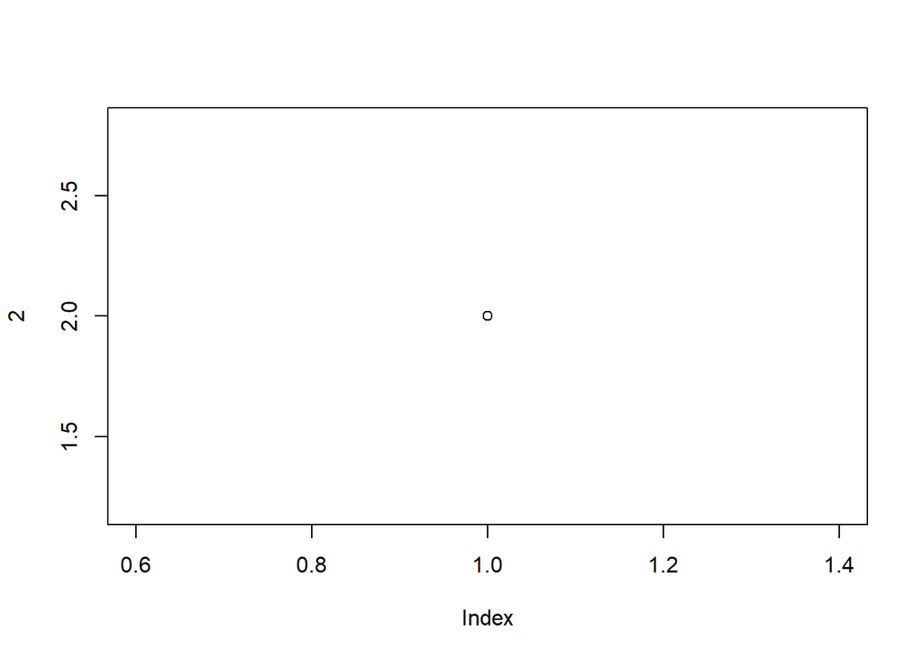

**The code provided by the candidate reads:**

```r
plot(2)
```

The candidate used 2 hints.

### Question 2 :

Make a query to get the average temperature in May (Month 5).

SQL was used to answer this question.

**The result provided by the candidate reads:**

| Ozone | Solar.R | Wind | Temp | Month | Day |
| --- | --- | --- | --- | --- | --- |
| 41 | 190 | 7.4 | 67 | 5 | 1 |
| 36 | 118 | 8.0 | 72 | 5 | 2 |
| 12 | 149 | 12.6 | 74 | 5 | 3 |
| 18 | 313 | 11.5 | 62 | 5 | 4 |
| NA | NA | 14.3 | 56 | 5 | 5 |

**The code provided by the candidate reads:**

```r
SELECT * FROM airquality LIMIT 5
```

The candidate used 0 hints.

### Question 3 :

Classical FizzBuzz: Print every number between 1 and 100, However for numbers that are multiples of 3 print “Fizz” and for numbers that are multiples of five print “Buzz.” For numbers that are multiples of both 3 and 5 print “FizzBuzz”.

**The applicant did not provide code.**

### Question 4 :

Sum of all prime numbers below 5000 that can be devided by 72

**The applicant did not provide code.**

### Question 5 :

Generate 100 random numbers with seed 50 and write a standard deviation function.

**The result provided by the candidate reads:**

[1] “42”

**The code provided by the candidate reads:**

```r
result = 42
```

The candidate used 0 hints.